# Séance 5.2: Paramètres de variation

## Distribution de la variable V6

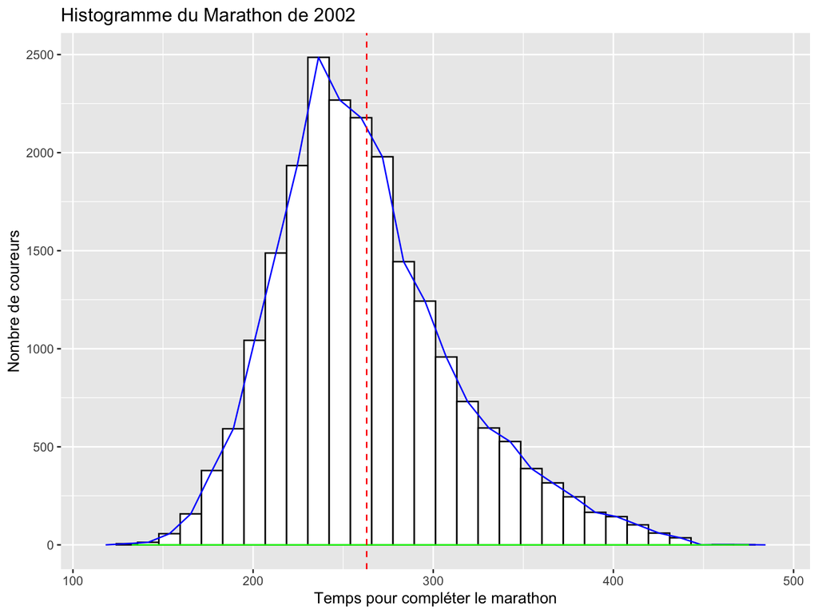

```r
fig1
```

## Boite à moustache

```r
class(marathon$V6)
```

```
## [1] "numeric"
```

```r
fig2 <-
  ggplot(marathon) +
  geom_boxplot(aes(y = V6)) +
  labs(title = "Diagramme de quartile",
       x = "",
       y = "Temps mis")
```

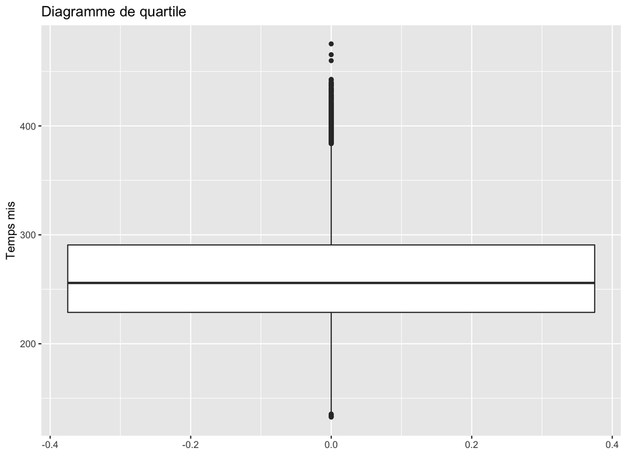

```r
fig2
```

Dans la plupart des cas, nous ne disposons pas de l'information de la population. Par exemple, pour estimer le revenu moyen de la population, nous devons disposer d'un échantillon.

# Échantillonnage aléatoire simple

## Échantillonnage aléatoire simple

On appelle échantillonnage aléatoire simple celui où chaque individu de la population **a la même chance d'être choisi** chaque fois que l'on tire une observation.

- Maintenant, prenons un échantillon de cette population et analysons ses caractéristiques

```r
set.seed(430)
marathon_S1 <- sample_n(marathon, 40, replace = FALSE)

head(marathon_S1)
```

```
##                    V1 V2 V3   V4  V5     V6
## 1    "Hellard Dwayne"  M 51 1196 USA 267.20
## 2       "Aron Narcis"  M 63  287 USA 278.40
## 3 "Owens Katherine H"  F 51  348 USA 272.72
## 4   "Takach Laura E."  F 28 4473 USA 380.85
## 5  "Frost Kathleen A"  F 46 1160 USA 301.33
## 6     "Minder Walter"  M 48 1667 SUI 274.08
```

## Échantillonnage aléatoire simple

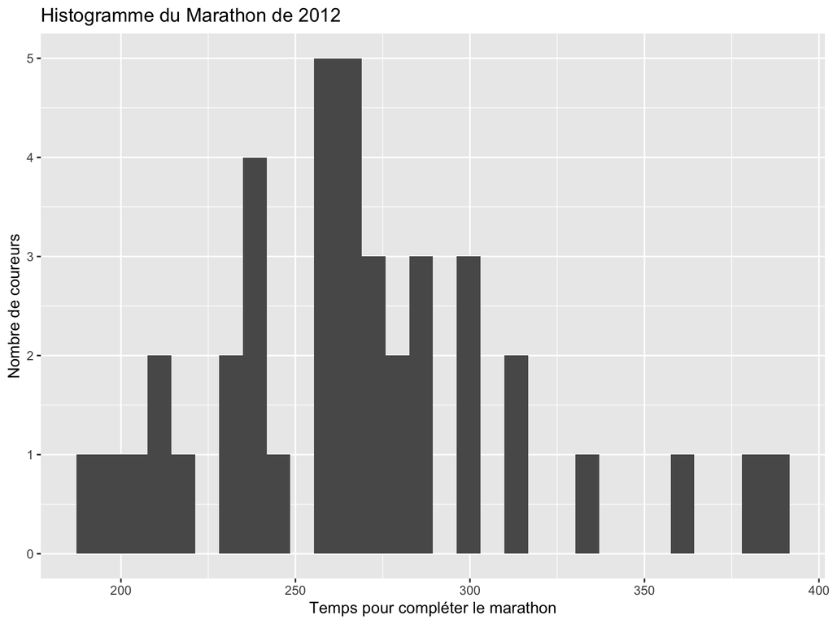

```r
ggplot(marathon_S1) +
  geom_histogram(aes(x = V6)) +
  labs(title = "Histogramme du Marathon de 2012",
       x = "Temps pour compléter le marathon",
       y = "Nombre de coureurs")
```

## Échantillonnage aléatoire simple

```r
caract_S1 <-
  marathon_S1 %>%
  summarise(moyenne = mean(V6, na.rm = TRUE),
            ecarttype = sd(V6, na.rm = TRUE),
            mediane = median(V6, na.rm = TRUE),
            Q1 = quantile(V6, prob = 0.25),
            Q3 = quantile(V6, prob = 0.75),
            variance = var(V6, na.rm = TRUE))%>%
  mutate(echantillon = factor("Echantillon S1"))

caract_S1
```

```
##    moyenne ecarttype mediane      Q1     Q3 variance    echantillon
## 1 268.5303  45.23583  263.25 237.465 284.04  2046.28 Echantillon S1
```

## Échantillonnage aléatoire simple - Comparaison de la moyenne d'échantillon et la moyenne de population

```r
# Comparaison
caract_c <- bind_rows(caract, caract_S1)
caract_c
```

[output not shown]

## Est-ce que cet échantillon est représentatif?

```r
library(summarytools)

freq(marathon$V2)
```

```
## Frequencies
## marathon$V2
## Type: Factor
##
##                Freq   % Valid   % Valid Cum.   % Total   % Total Cum.
## ----------- ------- --------- -------------- --------- --------------
##           F    8959     41.59          41.59     41.59          41.59
##           M   12582     58.41         100.00     58.41         100.00
##        <NA>       0                               0.00         100.00
##       Total   21541    100.00         100.00    100.00         100.00
```

```r
freq(marathon_S1$V2)
```

```
## Frequencies
## marathon_S1$V2
## Type: Factor
##
##               Freq   % Valid   % Valid Cum.   % Total   % Total Cum.
## ----------- ------ --------- -------------- --------- --------------
##           F     17     42.50          42.50     42.50          42.50
##           M     23     57.50         100.00     57.50         100.00
##        <NA>      0                               0.00         100.00
##       Total     40    100.00         100.00    100.00         100.00
```

# Échantillonnage aléatoire simple - distribution d'échantillonnage

## 100 échantillons de taille 10

```r
library(tidyverse)
```

- Ressource: https://stackoverflow.com/questions/42676348/multiple-random-sampling-in-r

```r
set.seed(123432)
marat_T10_R100 <- bind_rows(replicate(100, marathon %>% sample_n(10, replace = FALSE), simplify = F), .id = "Obs")

glimpse(marat_T10_R100)
```

```
## Rows: 1,000
## Columns: 7
## $ Obs <chr> "1", "1", "1", "1", "1", "1", "1", "1", "1", "1", "2", "2", "2", "…
## $ V1  <fct> "Wild Lindsey", "Bellman Catherine S", "Lynch John", "Opel Jonatho…
## $ V2  <fct> F, F, M, M, F, M, M, M, M, F, M, F, M, F, M, F, M, M, M, F, M, M, …
## $ V3  <int> 29, 56, 34, 36, 26, 25, 53, 48, 44, 36, 40, 38, 45, 32, 32, 46, 32…
## $ V4  <dbl> 189, 218, 2871, 330, 594, 49, 847, 238, 1919, 3360, 1943, 2642, 15…
## $ V5  <fct> USA, USA, USA, USA, USA, USA, USA, USA, USA, USA, USA, USA, CAN, U…
## $ V6  <dbl> 204.62, 301.40, 245.33, 178.10, 222.97, 157.22, 257.67, 208.78, 34…
```

## 100 échantillons de taille 10

```r
caract_marat_T10_R100 <-
  marat_T10_R100 %>%
  group_by(Obs) %>%
  summarise(moyenne = mean(V6, na.rm = TRUE),
            ecarttype = sd(V6, na.rm = TRUE)) %>%
  mutate(Taille = factor("10"))

glimpse(caract_marat_T10_R100)
```

```
## Rows: 100
## Columns: 4
## $ Obs       <chr> "1", "10", "100", "11", "12", "13", "14", "15", "16", "17", …
## $ moyenne   <dbl> 241.597, 272.800, 263.271, 304.598, 244.785, 292.280, 247.78…
## $ ecarttype <dbl> 58.93145, 47.12677, 46.92948, 40.34323, 44.58382, 76.09095, …
## $ Taille    <fct> 10, 10, 10, 10, 10, 10, 10, 10, 10, 10, 10, 10, 10, 10, 10, …
```

## 100 échantillons de taille 10 : Vérification du théorème central limite

```r
esperance_moyenne <- mean(caract_marat_T10_R100$moyenne)
erreurtype <- sd(caract_marat_T10_R100$moyenne)

population_moyenne <- mean(marathon$V6)
erreurtype_calcule <- sd(marathon$V6)/sqrt(10)

tcl_T10 <- bind_cols(e_m = esperance_moyenne, mu = population_moyenne, et = erreurtype, etc = erreurtype_calcule)

tcl_T10
```

```
## # A tibble: 1 × 4
##     e_m    mu    et   etc
##   <dbl> <dbl> <dbl> <dbl>
## 1  262.  263.  16.5  15.8
```

## 100 échantillons de taille 10 - Représentation graphique

```r
obslevel <- c(seq(1:100))

fig_T10_1 <-
  ggplot(caract_marat_T10_R100) +
  geom_point(aes(x = Obs, y = moyenne)) +
  geom_hline(aes(yintercept = mean(moyenne)), colour = "red") +
  geom_hline(data = marathon, aes(yintercept = mean(V6)), colour = "green") +
  scale_x_discrete(limits = obslevel) +
  theme(axis.text.x = element_text(angle = -60, hjust = 1, size = 6))
```

## 100 Échantillons de taille 10 - Représentation graphique

```r
fig_T10_2 <-
  ggplot(caract_marat_T10_R100) +
  geom_histogram(aes(x = moyenne)) +
  geom_vline(aes(xintercept = mean(moyenne)), colour = "red") +
  geom_vline(data = marathon, aes(xintercept = mean(V6)), color = "green")
```

## 100 Échantillons de taille 10 - Représentation graphique

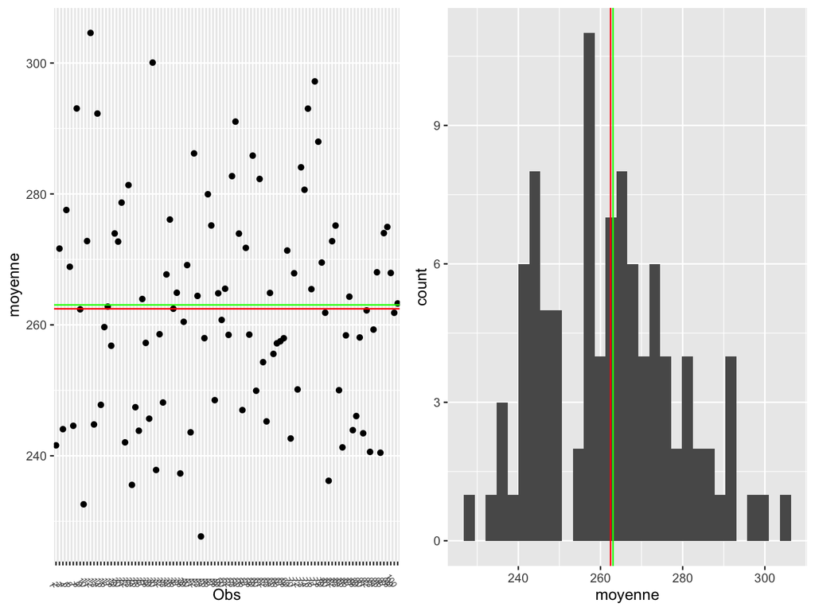

```r
library(ggpubr)

ggarrange(fig_T10_1, fig_T10_2, ncol = 2)
```

## 100 échantillons de taille 30

```r
set.seed(1234)
marat_T30_R100 <- bind_rows(replicate(100, marathon %>% sample_n(30, replace = FALSE), simplify = F), .id = "Obs")

caract_marat_T30_R100 <-
  marat_T30_R100 %>%
  group_by(Obs) %>%
  summarise(moyenne = mean(V6, na.rm = TRUE),
            ecarttype = sd(V6, na.rm = TRUE)) %>%
  mutate(Taille = factor("30"))

head(caract_marat_T30_R100)
```

```
## # A tibble: 6 × 4
##   Obs   moyenne ecarttype Taille
##   <chr>   <dbl>     <dbl> <fct>
## 1 1        260.      54.4 30
## 2 10       259.      45.6 30
## 3 100      268.      56.8 30
## 4 11       246.      44.1 30
## 5 12       272.      60.9 30
## 6 13       268.      49.1 30
```

## 100 échantillons de taille 30 : Vérification du théorème central limite

```r
esperance_moyenne <- mean(caract_marat_T30_R100$moyenne)
erreurtype <- sd(caract_marat_T30_R100$moyenne)

population_moyenne <- mean(marathon$V6)
erreurtype_calcule <- sd(marathon$V6)/sqrt(30)

tcl_T30 <- bind_cols(e_m = esperance_moyenne, mu = population_moyenne, et = erreurtype, etc = erreurtype_calcule)

tcl_T30
```

```
## # A tibble: 1 × 4
##     e_m    mu    et   etc
##   <dbl> <dbl> <dbl> <dbl>
## 1  264.  263.  8.95  9.13
```

## 100 échantillons de taille 30

```r
#obslevel <- c(seq(1:100))

fig_T30_1 <-
  ggplot(caract_marat_T30_R100) +
  geom_point(aes(x = Obs, y = moyenne)) +
  geom_hline(aes(yintercept = mean(moyenne)), colour = "red") +
  geom_hline(data = marathon, aes(yintercept = mean(V6)), colour = "green") +
  scale_x_discrete(limits = obslevel) +
  theme(axis.text.x = element_text(angle = -60, hjust = 1, size = 6))
```

## 100 Échantillons de taille 30 - Représentation graphique

```r
fig_T30_2 <-
  ggplot(caract_marat_T30_R100) +
  geom_histogram(aes(x = moyenne)) +
  geom_vline(aes(xintercept = mean(moyenne)), colour = "red") +
  geom_vline(data = marathon, aes(xintercept = mean(V6)), color = "green")
```

## 100 Échantillons de taille 30 - Représentation graphique

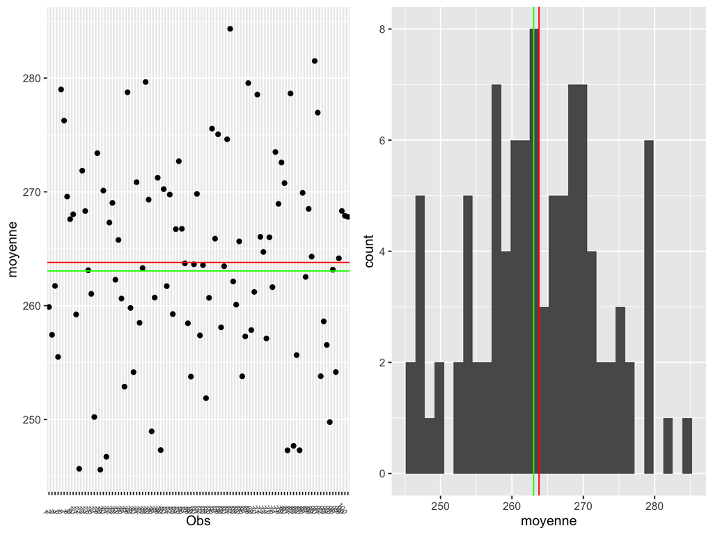

```r
ggarrange(fig_T30_1, fig_T30_2, ncol = 2)
```

## 100 échantillons de tailles 50

```r
set.seed(12302)
marat_T50_R100 <- bind_rows(replicate(100, marathon %>% sample_n(50, replace = FALSE), simplify = F), .id = "Obs")

caract_marat_T50_R100 <-
  marat_T50_R100 %>%
  group_by(Obs) %>%
  summarise(moyenne = mean(V6, na.rm = TRUE),
            ecarttype = sd(V6, na.rm = TRUE))%>%
  mutate(Taille = factor("50"))

glimpse(caract_marat_T50_R100)
```

```
## Rows: 100
## Columns: 4
## $ Obs       <chr> "1", "10", "100", "11", "12", "13", "14", "15", "16", "17", …
## $ moyenne   <dbl> 264.9438, 258.6650, 259.2164, 261.0740, 279.7738, 264.2202, …
## $ ecarttype <dbl> 46.45658, 49.27246, 59.92799, 38.43878, 50.41155, 42.75819, …
## $ Taille    <fct> 50, 50, 50, 50, 50, 50, 50, 50, 50, 50, 50, 50, 50, 50, 50, …
```

## 100 échantillons de taille 50 : Vérification du théorème central limite

```r
esperance_moyenne <- mean(caract_marat_T50_R100$moyenne)
erreurtype <- sd(caract_marat_T50_R100$moyenne)

population_moyenne <- mean(marathon$V6)
erreurtype_calcule <- sd(marathon$V6)/sqrt(50)

tcl_T50 <- bind_cols(e_m = esperance_moyenne, mu = population_moyenne, et = erreurtype, etc = erreurtype_calcule)

tcl_T50
```

```
## # A tibble: 1 × 4
##     e_m    mu    et   etc
##   <dbl> <dbl> <dbl> <dbl>
## 1  263.  263.  7.12  7.07
```

## 100 échantillons de taille 50

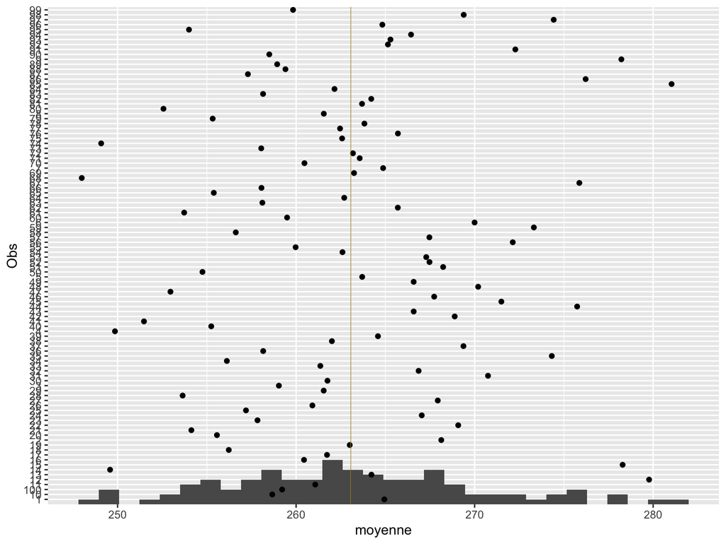

```r
ggplot(caract_marat_T50_R100) +
  geom_histogram(aes(x = moyenne)) +
  geom_point(aes(x = moyenne, y = Obs)) +
  geom_vline(aes(xintercept = mean(moyenne)), color = "red", size = 0.1) +
  geom_vline(data = marathon, aes(xintercept = mean(V6)), color = "green", size = 0.1)
```

## Comparaison de plusieurs distributions d'échantillonnage

```r
fig_comp <-
  ggplot() +
  geom_density(data = caract_marat_T10_R100, aes(x = moyenne), colour = "yellow", fill = "yellow") +
  geom_density(data = caract_marat_T30_R100, aes(x = moyenne), colour = "green") +
  geom_density(data = caract_marat_T50_R100, aes(x = moyenne), colour = "purple") +
  geom_density(data = marathon, aes(x = V6), colour = "red") +
  geom_vline(data = marathon, aes(xintercept = mean(V6)), color = "black")
```

## Comparaison de plusieurs distributions d'échantillonnage

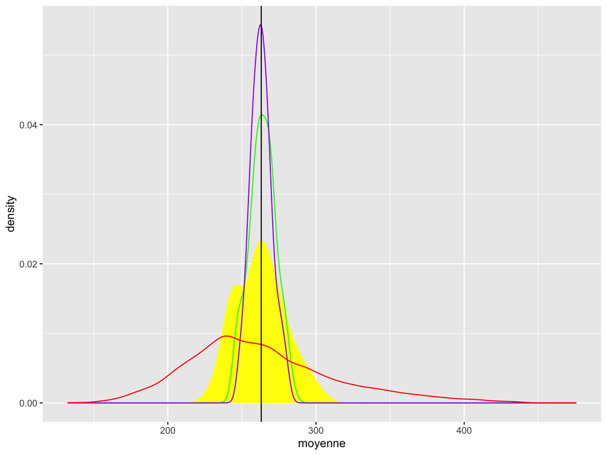

```r
fig_comp
```

## Fonction

Nous avons sélectionné plusieurs échantillons en répliquant la meême formule plusieurs fois. Essayons de voir si nous pouvons faire la meême chose en utilisant les fonctions.

```r
echantillon <- function(k, donnee, n){
  bind_rows(replicate(k, donnee %>% sample_n(n, replace = FALSE), simplify = F), .id = "Obs")

}

echantillon_t30_i100 <- echantillon(100, marathon, 30)

ech <- c("taille5", "taille6")
samp_k <- vector("list", length  = 2)
names(samp_k) <- names(ech)
for (i in 5:6) {
 samp_k[[i]] <- echantillon(100, marathon, i)
  }


#samp <- matrix(NA, nrow = length(echantillon), ncol = 7)
#names(samp) <- names(marathon)
#for (i in 5:6) {
# samp[i, ] <- echantillon(100, marathon, i)
#  }
```

# Intervalle de confiance

## Intervalle de confiance

```r
caract_marat_T30_R100 <-
  caract_marat_T30_R100 %>%
  mutate(erreurtype = sd(marathon$V6)/sqrt(30),
         c1 = erreurtype*1.96)

head(caract_marat_T30_R100)
```

```
## # A tibble: 6 × 6
##   Obs   moyenne ecarttype Taille erreurtype    c1
##   <chr>   <dbl>     <dbl> <fct>       <dbl> <dbl>
## 1 1        260.      54.4 30           9.13  17.9
## 2 10       259.      45.6 30           9.13  17.9
## 3 100      268.      56.8 30           9.13  17.9
## 4 11       246.      44.1 30           9.13  17.9
## 5 12       272.      60.9 30           9.13  17.9
## 6 13       268.      49.1 30           9.13  17.9
```

## Intervalle de confiance

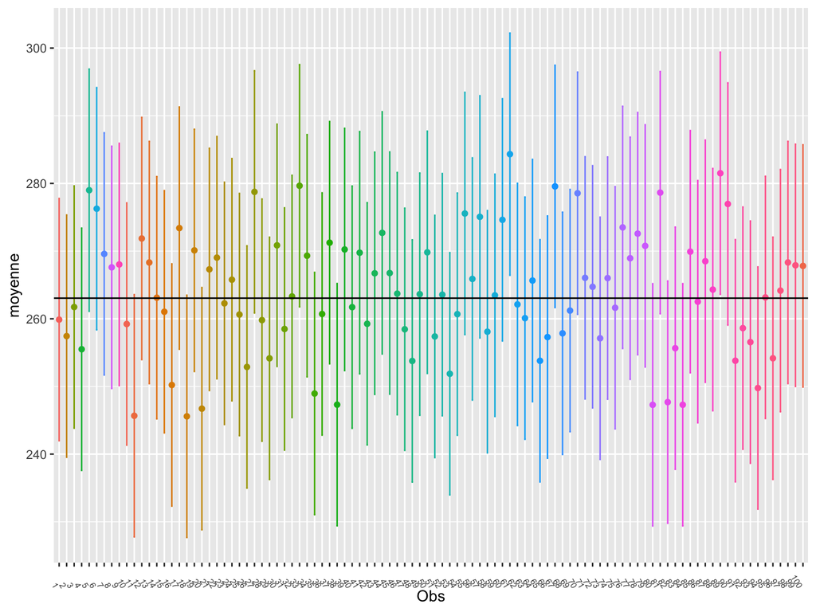

```r
ggplot(caract_marat_T30_R100, aes(x = Obs, y = moyenne, colour = Obs)) +
  geom_errorbar(aes(ymin = moyenne - c1, ymax = moyenne + c1), width=.2)+
  geom_point() +
  geom_hline(data = marathon, aes(yintercept = mean(V6)), colour = "black") +
  scale_x_discrete(limits = obslevel) +
  theme(axis.text.x = element_text(angle = -60, hjust = 1, size = 6), legend.position = "none")
```

## Intervalle de confiance

- Dans les faits, on ne connait rien sur la population, donc on va remplacer l'écart type de la population par l'écart type de l'échantillon

```r
caract_marat_T30_R100
```

```
## # A tibble: 100 × 6
##    Obs   moyenne ecarttype Taille erreurtype    c1
##    <chr>   <dbl>     <dbl> <fct>       <dbl> <dbl>
##  1 1        260.      54.4 30           9.13  17.9
##  2 10       259.      45.6 30           9.13  17.9
##  3 100      268.      56.8 30           9.13  17.9
##  4 11       246.      44.1 30           9.13  17.9
##  5 12       272.      60.9 30           9.13  17.9
##  6 13       268.      49.1 30           9.13  17.9
##  7 14       263.      43.2 30           9.13  17.9
##  8 15       261.      49.5 30           9.13  17.9
##  9 16       250.      44.4 30           9.13  17.9
## 10 17       273.      70.1 30           9.13  17.9
## # … with 90 more rows
```

```r
caract_marat_T30_R100 <-
  caract_marat_T30_R100 %>%
  mutate(erreurtype_estime = ecarttype/sqrt(30),
         c1_estime = erreurtype_estime*1.96)

head(caract_marat_T30_R100)
```

```
## # A tibble: 6 × 8
##   Obs   moyenne ecarttype Taille erreurtype    c1 erreurtype_estime c1_estime
##   <chr>   <dbl>     <dbl> <fct>       <dbl> <dbl>             <dbl>     <dbl>
## 1 1        260.      54.4 30           9.13  17.9              9.93      19.5
## 2 10       259.      45.6 30           9.13  17.9              8.33      16.3
## 3 100      268.      56.8 30           9.13  17.9             10.4       20.3
## 4 11       246.      44.1 30           9.13  17.9              8.05      15.8
## 5 12       272.      60.9 30           9.13  17.9             11.1       21.8
## 6 13       268.      49.1 30           9.13  17.9              8.97      17.6
```

## Intervalle de confiance*

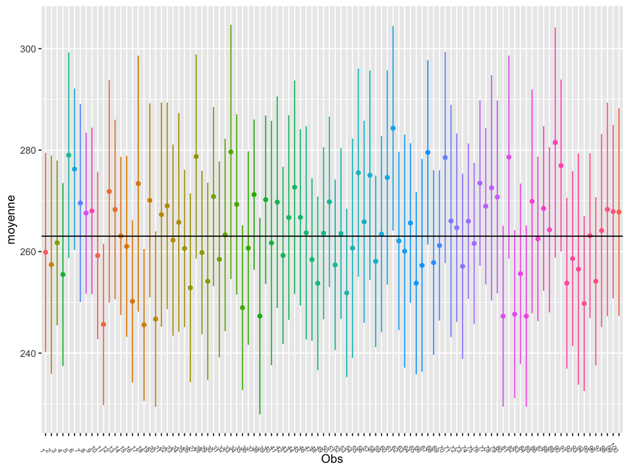

```r
ggplot(caract_marat_T30_R100, aes(x = Obs, y = moyenne, colour = Obs)) +
  geom_errorbar(aes(ymin = moyenne - c1_estime, ymax = moyenne + c1_estime), width=.2)+
  geom_point() +
  geom_hline(data = marathon, aes(yintercept = mean(V6)), colour = "black") +
  scale_x_discrete(limits = obslevel) +
  theme(axis.text.x = element_text(angle = -60, hjust = 1, size = 6), legend.position = "none")
```

## Quels sont les échantillons qui s'écartent de deux écart types de la moyenne

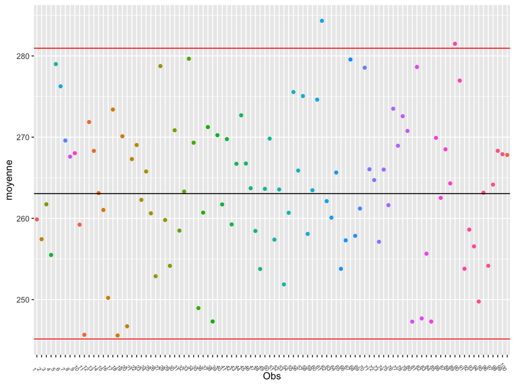

```r
ggplot(caract_marat_T30_R100, aes(x = Obs, y = moyenne, colour = Obs)) +
  geom_point() +
  geom_hline(data = marathon, aes(yintercept = (mean(V6) - 1.96*sd(V6)/sqrt(30))), colour = "red") +
  geom_hline(data = marathon, aes(yintercept = (mean(V6) + 1.96*sd(V6)/sqrt(30))), colour = "red") +
  geom_hline(data = marathon, aes(yintercept = mean(V6)), colour = "black") +
  scale_x_discrete(limits = obslevel) +
  theme(axis.text.x = element_text(angle = -60, hjust = 1, size = 6), legend.position = "none")
```

## Problèmes avec l'échantillonnage aléatoire

- La base de sondage n'est pas toujours disponible (échantillonnage systématique)
- Très couteux et non éfficient
- Ne permet pas d'estimer les paramètres de petits groupes.
- Aussi dans les faits, cette technique n'est pratiquement jamais utilisée seule.
- Elle est toujours combinée à plusieurs autres approches
- Par exemple, les données de `dhs_ipv_benin` utilisent une combinaison de plusieurs méthodes
- Échantillonnage par grappe
- Échantillonnage stratifié
- Échantillonnage aléatoire
- Je vais vous présenter rapidement certains de ces techniques:
- Échantillonnage stratifié
- Échantillonnage par grappes

# Échantillonnage stratifié

## Régardons les distributions des femmes et des hommes dans la population des courreurs

- Pour changer la couleur de contenu des graphiques: https://rpubs.com/woobe/ggplot2_ref_part02

```r
fig_s1 <-
  ggplot(marathon) +
  geom_histogram(aes(x = V6, fill = V2)) +
  scale_fill_brewer(palette="Set2")+
  labs(title = "Histogramme du Marathon de 2012",
       x = "Temps pour compléter le marathon",
       y = "Nombre de coureurs")
```

## Régardons les distributions des femmes et des hommes dans la population des courreurs

```r
fig_S2 <-
  ggplot(marathon) +
  geom_histogram(aes(x = V6, fill = V2)) +
  scale_fill_brewer(palette="Set2")+
  facet_wrap(~V2) +
  geom_vline(aes(xintercept = mean(V6)), col = "red") +
  labs(title = "Histogramme du Marathon de 2012",
       x = "Temps pour compléter le marathon",
       y = "Nombre de coureurs")
```

## Régardons les distributions des femmes et des hommes dans la population des courreurs

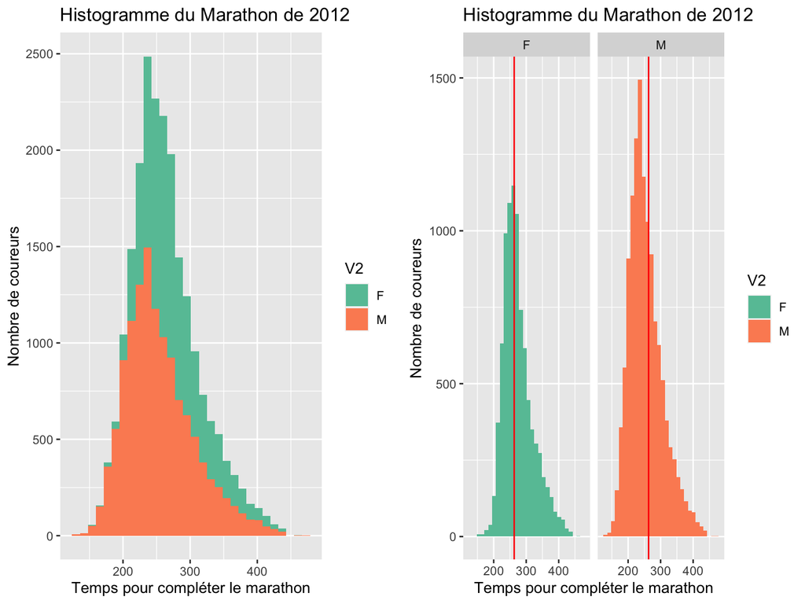

```r
ggarrange(fig_s1, fig_S2, ncol = 2)
```

## Combien avons-nous d'hommes et de femmes?

- La distribution des femmes peut eêtre différente de la distribution des hommes, dans ce cas, on va utiliser comme variable de stratification le sexe.

```r
freq(marathon$V2)
```

```
## Frequencies
## marathon$V2
## Type: Factor
##
##                Freq   % Valid   % Valid Cum.   % Total   % Total Cum.
## ----------- ------- --------- -------------- --------- --------------
##           F    8959     41.59          41.59     41.59          41.59
##           M   12582     58.41         100.00     58.41         100.00
##        <NA>       0                               0.00         100.00
##       Total   21541    100.00         100.00    100.00         100.00
```

```r
#freq(marathon$V5)
```

## Échantillonnage stratifié

Vous pourriez préférer l'échantillonnage stratifié à l'échantillonnage aléatoire simple pour plusieurs raisons.

1. Permet d'augmenter le degré de confiance pour les généralisations à des sous-groupes ou des secteurs particuliers.
- Cela garantit que vous pourrez représenter non seulement la population totale, mais également des sous-groupes clés de la population, en particulier les groupes minoritaires.
- Si vous voulez pouvoir parler de sous-groupes, c’est peut-être le seul moyen de s’assurer efficacement de le faire.
- Si le sous-groupe est extrêmement petit, vous pouvez utiliser différentes fractions d'échantillonnage (f) dans les différentes strates pour sur-échantillonner de manière aléatoire le petit groupe.

## Échantillonnage stratifié

2. L'échantillonnage aléatoire stratifié a plus de précision statistique que l'échantillonnage aléatoire simple si les strates ou les groupes sont homogènes.
- S'ils le sont, vous devez vous attendre à ce que la variabilité au sein des groupes soit inférieure à celle de la population dans son ensemble. L'échantillonnage stratifié profite de ce fait.

## Échantillonnage stratifié : Procédure

- La population est divisée en groupes homogènes et mutuellement exclusifs (strates), tels que des quartiers, puis les observations sont sélectionnées de manière aléatoire au sein de chaque strate.
- **NB:** Contrairement à l'échantillonnage par grappe, où les strates sont presque toujours spatiales, les strates sont généralement choisies pour être les facteurs de confusion de l'analyse démographique (âge, sexe, etc.) mais peuvent aussi être spatiales.
- L'objectif principal de l'échantillonnage stratifié est de réduire l'erreur d'échantillonnage.

# Échantillonnage par grappe